# Source memory performance for objects inside the rooms

# 1 Visual inspection of the data

# 2 Novelty Benefits

## 2.1 Compare mean accuracy between *novel* and *familiar* rooms

## 2.2 Check the data

**Is there any corrected hit rate < 0?**

There are 0 negative value out of a total of 80 participants.

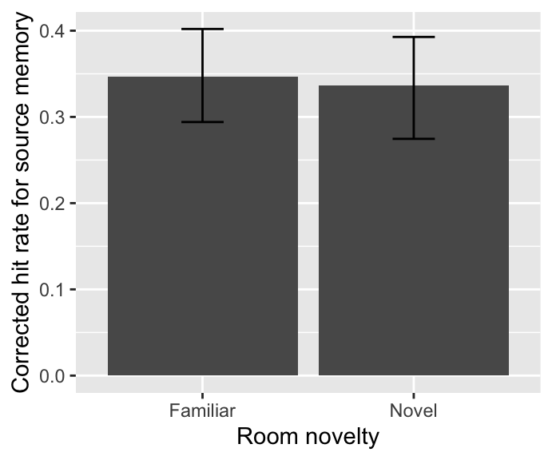

```
##       Group      Mean        SD  N
## 1:    Novel 0.3365532 0.1912242 40
## 2: Familiar 0.3467452 0.1729727 40
```

```
##
##  Paired t-test
##
## data:  SrcAcc by Group
## t = 0.39582, df = 39, p-value = 0.6944
## alternative hypothesis: true difference in means is not equal to 0
## 95 percent confidence interval:
##  -0.04189103  0.06227501
## sample estimates:
## mean of the differences
##              0.01019199
```

## 2.3 Any difference between *Early* and *Later* object groups?

**Is there any corrected hit rate < 0?**

There are 7 negative values out of a total of 160 participants.

```
##    SubjectNo    Group ObjOrdGrp MeanCurRt   MeanDur     SFHit      SHit
## 1:       P03    Novel     Later  5.666667       NaN 0.7777778 0.7777778
## 2:       P03 Familiar     Later  3.571429       NaN 0.7142857 0.7142857
## 3:       P63    Novel     Early  6.000000 120.46042 1.0000000 0.8888889
## 4:       P73    Novel     Later  6.333333  98.06488 0.6666667 0.3333333
## 5:       P76 Familiar     Later  2.333333 103.24990 0.7777778 0.6666667
## 6:       P82    Novel     Early  5.333333 119.54276 0.8888889 0.4444444
## 7:       P86    Novel     Later  6.333333  96.12738 0.3333333 0.2222222
##    SrcHit    SFFalse     SFalse   SrcFalse      SFAcc       SAcc
## 1:      0 0.15000000 0.05000000 0.05000000  0.6277778 0.72777778
## 2:      0 0.15000000 0.05000000 0.05000000  0.5642857 0.66428571
## 3:      0 0.05555556 0.00000000 0.01851852  0.9444444 0.88888889
## 4:      0 0.16666667 0.00000000 0.01851852  0.5000000 0.33333333
## 5:      0 0.27777778 0.11111111 0.09259259  0.5000000 0.55555556
## 6:      0 0.50000000 0.05555556 0.14814815  0.3888889 0.38888889
## 7:      0 0.44444444 0.16666667 0.11111111 -0.1111111 0.05555556
##         SrcAcc
## 1: -0.05000000
## 2: -0.05000000
## 3: -0.01851852
## 4: -0.01851852
## 5: -0.09259259
## 6: -0.14814815
## 7: -0.11111111
```

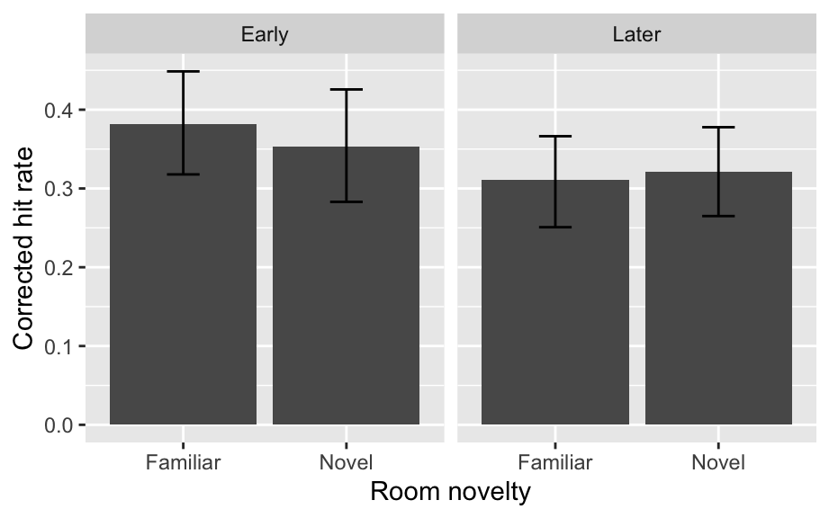

```
##       Group ObjOrdGrp      Mean        SD  N
## 1:    Novel     Early 0.3526888 0.2389914 40
## 2:    Novel     Later 0.3207444 0.1864850 40
## 3: Familiar     Later 0.3106750 0.1825902 40
## 4: Familiar     Early 0.3818555 0.2200031 40
```

```
## $ANOVA
##            Effect DFn DFd         F         p p<.05          ges
## 2           Group   1  39 0.1379542 0.7123336       0.0005382783
## 3       ObjOrdGrp   1  39 5.2744365 0.0270966     * 0.0154618263
## 4 Group:ObjOrdGrp   1  39 0.7561920 0.3898435       0.0022682244
```

# 3 Curiosity Enhancement

## 3.1 Check the data

### 3.1.1 Is there any corrected hit rate < 0?

#### 3.1.1.1 For the data per room

- There are 19 negative values out of a total of 239 values.

```
##     SubjectNo     Context    Group CurRating RoomOrder  Duration     SFHit
##  1:       P01 StorageRoom    Novel         7     First        NA 0.1666667
##  2:       P03     Bedroom Familiar         5     First        NA 0.5000000
##  3:       P03         Gym Familiar         1    Second        NA 0.6000000
##  4:       P03     Library    Novel         7     First        NA 0.6666667
##  5:       P04  LivingRoom    Novel         3    Second        NA 1.0000000
##  6:       P11 StorageRoom    Novel         4     First        NA 0.8333333
##  7:       P63   Classroom    Novel         6    Second  56.68444 1.0000000
##  8:       P63  LivingRoom Familiar         3     First  77.89058 0.8333333
##  9:       P67 StorageRoom Familiar         1    Second  74.63424 1.0000000
## 10:       P73         Gym Familiar         1    Second 100.57296 0.6666667
## 11:       P73     Library    Novel         6     First  86.43149 0.8333333
## 12:       P73  LivingRoom    Novel         6     First 149.44845 0.5000000
## 13:       P74         Gym    Novel         6    Second 105.72799 0.8333333
## 14:       P74  LivingRoom Familiar         2     First  88.86257 1.0000000
```

[output cut: 45 more lines]

#### 3.1.1.2 For the data per curiosity group

- There are 2 negative value for curiosity group (1 ~ 3 and 5 ~ 7) out of a total of 78 values.

```
##    SubjectNo CurGrp  MeanDur     SFHit      SHit     SrcHit   SFFalse
## 1:       P76    Low 81.32444 0.8333333 0.6666667 0.08333333 0.2777778
## 2:       P86    Low 95.57637 0.5833333 0.1666667 0.08333333 0.4444444
##       SFalse   SrcFalse     SFAcc      SAcc       SrcAcc
## 1: 0.1111111 0.09259259 0.5555556 0.5555556 -0.009259259
## 2: 0.1666667 0.11111111 0.1388889 0.0000000 -0.027777778
```

#### 3.1.1.3 For the data per curiosity group (median)

- There are 1 negative value for curiosity group (median) out of a total of 79 values.

```
##    SubjectNo CurGrpMedian  MeanDur     SFHit      SHit     SrcHit
## 1:       P76          Low 81.32444 0.8333333 0.6666667 0.08333333
##      SFFalse    SFalse   SrcFalse     SFAcc      SAcc       SrcAcc
## 1: 0.2777778 0.1111111 0.09259259 0.5555556 0.5555556 -0.009259259
```

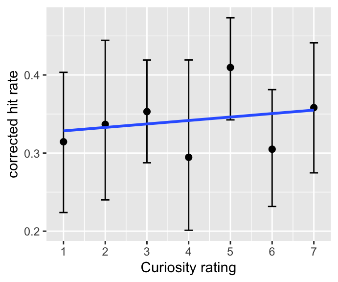

## 3.3 Testing the relationship between mean accuracy of item memory and curiosity rating

Build models with item memory accuracy as $y$ and examine effects of curiosity rating by including it into the model and then comparing the model fits.

- `baseline.rating` is the model with only an intercept, showing no change in item memory as a function of curiosity rating.
- `rating.intercept` is the model with $\small CuriosityRating$ included, showing the effects of curiosity rating.
- `rating.slope` is the model allowing the slope (i.e., relationship between item memory and curiosity rating) varying across participants.

```
##                  Model df       AIC        BIC   logLik   Test   L.Ratio
## baseline.rating      1  3 -21.40250 -10.973107 13.70125
## rating.intercept     2  4 -19.78401  -5.878157 13.89200 1 vs 2 0.3815137
## rating.slope         3  6 -15.77951   5.079273 13.88975 2 vs 3 0.0045027
##                  p-value
## baseline.rating
## rating.intercept  0.5368
## rating.slope      0.9978
```

## 3.4 Check the curiosity groups

### 3.4.1 Separate the groups according to the rating

- *High*: curiosity rating > 4
- *Low*: curiosity rating < 4
- For curiosity rating = 4, discarded

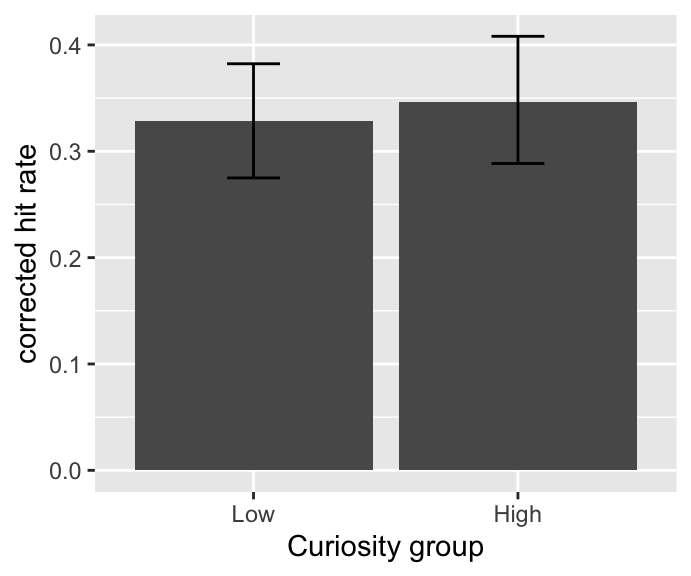

```
##    CurGrp      Mean        SD  N
## 1:   High 0.3465083 0.1935414 40
## 2:    Low 0.3280297 0.1763392 38
```

```
## Linear mixed-effects model fit by maximum likelihood
##  Data: inside.hit.rate.curiosity.group
##         AIC       BIC   logLik
##   -54.69636 -40.55611 33.34818
##
## Random effects:
##  Formula: ~1 + CurGrp | SubjectNo
##  Structure: General positive-definite, Log-Cholesky parametrization
##             StdDev     Corr
## (Intercept) 0.16066635 (Intr)
## CurGrpHigh  0.11970674 -0.199
## Residual    0.06362605
##
## Fixed effects: SrcAcc ~ CurGrp
##                 Value  Std.Error DF   t-value p-value
## (Intercept) 0.3267326 0.02808308 39 11.634502  0.0000
## CurGrpHigh  0.0197757 0.02445148 37  0.808773  0.4238
##  Correlation:
##            (Intr)
## CurGrpHigh -0.327
##
## Standardized Within-Group Residuals:
##         Min          Q1         Med          Q3         Max
## -1.23346048 -0.26661159 -0.03746974  0.33341203  0.92489285
##
## Number of Observations: 78
## Number of Groups: 40
```

#### 3.4.1.1 Curiosity groups and temporal order of the objects

##### 3.4.1.1.1 Check the data

- **Is there any corrected hit rate < 0?**
  - There are 11 negative values out of a total of 190 values.

```
##     SubjectNo CurGrp ObjOrdGrp     SFHit      SHit SrcHit    SFFalse
##  1:       P02   High     Early 0.6666667 0.6666667      0 0.31578947
##  2:       P02    Low     Later 1.0000000 1.0000000      0 0.31578947
##  3:       P03   High     Later 0.6666667 0.6666667      0 0.15000000
##  4:       P03    Low     Later 1.0000000 1.0000000      0 0.15000000
##  5:       P04   High     Early 0.8333333 0.8333333      0 0.31578947
##  6:       P63   High     Early 1.0000000 0.8888889      0 0.05555556
##  7:       P73   High     Later 0.6666667 0.3333333      0 0.16666667
##  8:       P76    Low     Later 0.6666667 0.5000000      0 0.27777778
##  9:       P82   High     Early 0.8333333 0.1666667      0 0.50000000
## 10:       P86   High     Later 0.3333333 0.2222222      0 0.44444444
## 11:       P86    Low     Later 0.5000000 0.1666667      0 0.44444444
##         SFalse   SrcFalse       SFAcc       SAcc      SrcAcc
##  1: 0.00000000 0.01754386  0.35087719 0.66666667 -0.01754386
##  2: 0.00000000 0.01754386  0.68421053 1.00000000 -0.01754386
##  3: 0.05000000 0.05000000  0.51666667 0.61666667 -0.05000000
##  4: 0.05000000 0.05000000  0.85000000 0.95000000 -0.05000000
##  5: 0.26315789 0.03508772  0.51754386 0.57017544 -0.03508772
##  6: 0.00000000 0.01851852  0.94444444 0.88888889 -0.01851852
##  7: 0.00000000 0.01851852  0.50000000 0.33333333 -0.01851852
##  8: 0.11111111 0.09259259  0.38888889 0.38888889 -0.09259259
##  9: 0.05555556 0.14814815  0.33333333 0.11111111 -0.14814815
## 10: 0.16666667 0.11111111 -0.11111111 0.05555556 -0.11111111
## 11: 0.16666667 0.11111111  0.05555556 0.00000000 -0.11111111
```

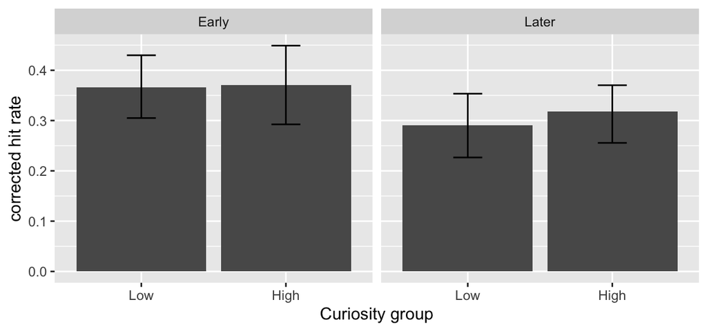

```
##    CurGrp ObjOrdGrp      Mean        SD  N
## 1:   High     Early 0.3708833 0.2563034 40
## 2:   High     Later 0.3175500 0.1933753 40
## 3:    Low     Later 0.2901842 0.2042206 38
## 4:    Low     Early 0.3654766 0.2032346 38
```

```
##           Model df       AIC       BIC   logLik   Test  L.Ratio p-value
## baseline      1  8 -60.84184 -36.44299 38.42092
## ord.model     2  9 -64.92665 -37.47794 41.46332 1 vs 2 6.084806  0.0136
## cur.model     3 10 -63.45857 -32.96001 41.72929 2 vs 3 0.531927  0.4658
## int.model     4 11 -61.66191 -28.11349 41.83095 3 vs 4 0.203334  0.6520
```

```
## Linear mixed-effects model fit by maximum likelihood
##  Data: inside.hit.rate.item.order.curiosity[!is.na(CurGrp)]
##         AIC       BIC   logLik
##   -61.66191 -28.11349 41.83095
##
## Random effects:
##  Formula: ~1 + CurGrp + ObjOrdGrp | SubjectNo
##  Structure: General positive-definite, Log-Cholesky parametrization
##                StdDev     Corr
## (Intercept)    0.15096816 (Intr) CrGrpH
## CurGrpHigh     0.03268687  0.724
## ObjOrdGrpLater 0.03656454 -0.786 -0.944
## Residual       0.15024607
##
## Fixed effects: SrcAcc ~ ObjOrdGrp + CurGrp + ObjOrdGrp:CurGrp
##                                Value  Std.Error  DF   t-value p-value
## (Intercept)                0.3635135 0.03469759 113 10.476622  0.0000
## ObjOrdGrpLater            -0.0749328 0.03542064 113 -2.115511  0.0366
## CurGrpHigh                 0.0073698 0.03501079 113  0.210501  0.8337
## ObjOrdGrpLater:CurGrpHigh  0.0215994 0.04877207 113  0.442864  0.6587
##  Correlation:
##                           (Intr) ObjOGL CrGrpH
## ObjOrdGrpLater            -0.588
## CurGrpHigh                -0.434  0.470
## ObjOrdGrpLater:CurGrpHigh  0.361 -0.706 -0.697
##
## Standardized Within-Group Residuals:
##         Min          Q1         Med          Q3         Max
## -2.18050783 -0.64584544  0.02350868  0.61756165  2.15817486
##
## Number of Observations: 156
## Number of Groups: 40
```

##### 3.4.1.1.2 *Post hoc*

```
##
##   Simultaneous Tests for General Linear Hypotheses
##
## Fit: lme.formula(fixed = SrcAcc ~ ObjOrdGrp + CurGrp + ObjOrdGrp:CurGrp,
##     data = inside.hit.rate.item.order.curiosity[!is.na(CurGrp)],
##     random = ~1 + CurGrp + ObjOrdGrp | SubjectNo, method = "ML",
##     na.action = na.exclude, control = list(msMaxIter = 500, opt = "optim",
##         msVerbose = FALSE))
##
## Linear Hypotheses:
##                          Estimate Std. Error z value Pr(>|z|)
## Early: High vs. Low == 0  0.00737    0.03456   0.213    0.831
## Late:  High vs. Low == 0  0.02897    0.03453   0.839    0.401
## (Adjusted p values reported -- none method)
```

### 3.4.2 Separate the groups according to the median rating of each participant

- *High*: curiosity rating > median of the participant
- *Low*: curiosity rating < median of the participant

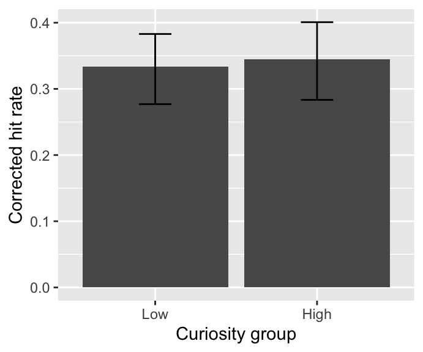

```
## Linear mixed-effects model fit by maximum likelihood
##  Data: inside.hit.rate.curiosity.group.median
##         AIC       BIC   logLik
##   -57.11271 -42.89602 34.55635
##
## Random effects:
##  Formula: ~1 + CurGrpMedian | SubjectNo
##  Structure: General positive-definite, Log-Cholesky parametrization
##                  StdDev    Corr
## (Intercept)      0.1616591 (Intr)
## CurGrpMedianHigh 0.1163067 -0.178
## Residual         0.0630181
##
## Fixed effects: SrcAcc ~ CurGrpMedian
##                      Value  Std.Error DF   t-value p-value
## (Intercept)      0.3337652 0.02778799 39 12.011135  0.0000
## CurGrpMedianHigh 0.0157809 0.02374100 38  0.664711  0.5102
##  Correlation:
##                  (Intr)
## CurGrpMedianHigh -0.285
##
## Standardized Within-Group Residuals:
##          Min           Q1          Med           Q3          Max
## -1.285056920 -0.269988837  0.004146468  0.360052471  0.958419569
##
## Number of Observations: 79
## Number of Groups: 40
```

#### 3.4.2.1 Curiosity groups and temporal order of the objects

##### 3.4.2.1.1 Check the data

- **Is there any corrected hit rate < 0?**
  - There are 10 negative values out of a total of 168 participants.

```
##     SubjectNo CurGrpMedian ObjOrdGrp     SFHit      SHit SrcHit    SFFalse
##  1:       P02         High     Early 0.6666667 0.6666667      0 0.31578947
##  2:       P02          Low     Later 1.0000000 1.0000000      0 0.31578947
##  3:       P03         High     Later 0.6666667 0.6666667      0 0.15000000
##  4:       P03          Low     Later 0.8571429 0.8571429      0 0.15000000
##  5:       P04         High     Early 0.8888889 0.8888889      0 0.31578947
##  6:       P63         High     Early 1.0000000 0.8888889      0 0.05555556
##  7:       P73         High     Later 0.6666667 0.3333333      0 0.16666667
##  8:       P76          Low     Later 0.6666667 0.5000000      0 0.27777778
##  9:       P82         High     Early 0.8888889 0.4444444      0 0.50000000
## 10:       P86         High     Later 0.3333333 0.2222222      0 0.44444444
##         SFalse   SrcFalse      SFAcc       SAcc      SrcAcc
##  1: 0.00000000 0.01754386  0.3508772 0.66666667 -0.01754386
##  2: 0.00000000 0.01754386  0.6842105 1.00000000 -0.01754386
##  3: 0.05000000 0.05000000  0.5166667 0.61666667 -0.05000000
##  4: 0.05000000 0.05000000  0.7071429 0.80714286 -0.05000000
##  5: 0.26315789 0.03508772  0.5730994 0.62573099 -0.03508772
##  6: 0.00000000 0.01851852  0.9444444 0.88888889 -0.01851852
##  7: 0.00000000 0.01851852  0.5000000 0.33333333 -0.01851852
##  8: 0.11111111 0.09259259  0.3888889 0.38888889 -0.09259259
##  9: 0.05555556 0.14814815  0.3888889 0.38888889 -0.14814815
## 10: 0.16666667 0.11111111 -0.1111111 0.05555556 -0.11111111
```

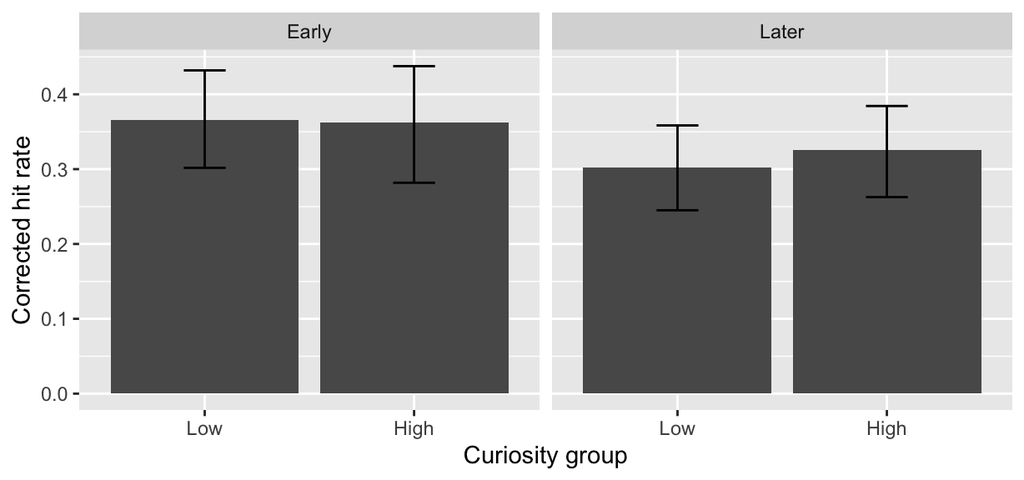

```
##    CurGrpMedian ObjOrdGrp      Mean        SD  N
## 1:         High     Early 0.3620883 0.2508536 39
## 2:         High     Later 0.3250512 0.1940166 39
## 3:          Low     Later 0.3023416 0.1941584 40
## 4:          Low     Early 0.3651888 0.2096820 40
```

```
##           Model df       AIC       BIC   logLik   Test  L.Ratio p-value
## baseline      1  8 -72.44735 -47.94659 44.22368
## ord.model     2  9 -74.86732 -47.30396 46.43366 1 vs 2 4.419967  0.0355
## cur.model     3 10 -73.21838 -42.59243 46.60919 2 vs 3 0.351067  0.5535
## int.model     4 11 -71.50777 -37.81923 46.75389 3 vs 4 0.289386  0.5906
```

```
## Linear mixed-effects model fit by maximum likelihood
##  Data: inside.hit.rate.item.order.curiosity.median[!is.na(CurGrpMedian)]
##         AIC       BIC   logLik
##   -71.50777 -37.81923 46.75389
##
## Random effects:
##  Formula: ~1 + CurGrpMedian + ObjOrdGrp | SubjectNo
##  Structure: General positive-definite, Log-Cholesky parametrization
##                  StdDev     Corr
## (Intercept)      0.16091154 (Intr) CrGrMH
## CurGrpMedianHigh 0.04446963  0.315
## ObjOrdGrpLater   0.04332369 -0.874  0.114
## Residual         0.14315566
##
## Fixed effects: SrcAcc ~ ObjOrdGrp + CurGrpMedian + ObjOrdGrp:CurGrpMedian
##                                      Value  Std.Error  DF   t-value
## (Intercept)                      0.3651888 0.03449308 115 10.587308
## ObjOrdGrpLater                  -0.0628472 0.03315772 115 -1.895402
## CurGrpMedianHigh                 0.0019545 0.03351193 115  0.058322
## ObjOrdGrpLater:CurGrpMedianHigh  0.0247503 0.04615395 115  0.536256
##                                 p-value
## (Intercept)                      0.0000
## ObjOrdGrpLater                   0.0605
## CurGrpMedianHigh                 0.9536
## ObjOrdGrpLater:CurGrpMedianHigh  0.5928
##  Correlation:
##                                 (Intr) ObjOGL CrGrMH
## ObjOrdGrpLater                  -0.596
## CurGrpMedianHigh                -0.405  0.478
## ObjOrdGrpLater:CurGrpMedianHigh  0.330 -0.687 -0.689
##
## Standardized Within-Group Residuals:
##         Min          Q1         Med          Q3         Max
## -2.02412586 -0.59865810 -0.02153929  0.60919798  2.35754090
##
## Number of Observations: 158
## Number of Groups: 40
```